# Introdução

Atualmente, as nações estão cada vez mais interligadas, realizando transações envolvendo uma ampla gama de bens e, em alguns casos, até mesmo serviços. Em um mundo cada vez mais globalizado, as cadeias de abastecimento de um país, denominado país X, estão intrinsecamente ligadas às de outros países, como o país Y. Essa interconexão torna-se particularmente evidente em momentos de crise, como a crise do subprime em 2008 e a pandemia de COVID-19 em 2020. Nessas ocasiões, a cadeia global de abastecimento é afetada, seja devido à redução da demanda ou da oferta.

Economistas têm se dedicado, ao longo do tempo, ao estudo dos desafios relacionados ao comércio internacional. Um dos pioneiros nesse campo foi David Ricardo, que desenvolveu a teoria das vantagens comparativas. Assim como Ricardo, o laureado com o Prêmio Nobel de Economia, Paul Krugman, dedicou-se a compreender as implicações do comércio entre duas nações. A teoria elaborada por Krugman e seus colegas ficou conhecida como "Nova Economia Internacional" (Gontijo, 2007) e revolucionou a maneira como os economistas compreendem as relações entre as nações.

Nesse contexto, este documento tem como objetivo principal analisar as condições do comércio exterior do Brasil, com foco especial na análise das exportações brasileiras. Historicamente, o Brasil tem dependido de suas exportações para equilibrar sua balança comercial. Em determinados momentos, as autoridades optaram pelo modelo de substituição de importações para fortalecer o mercado interno e aumentar a produção nacional de bens e equipamentos. No entanto, ao longo do tempo, esse modelo perdeu eficácia (Lima, 2011), devido à pressão exercida pelos preços das importações sobre a balança comercial.

Para avaliar os dados históricos, foram selecionados as dez localidades e produtos exportados que apresentaram o maior volume acumulado, tanto em termos de peso quanto de valor monetário, ao longo da série temporal. Essa escolha tem como objetivo analisar o comportamento das exportações do país.

É importante destacar que a seleção dessas dez localidades e produtos foi feita de forma arbitrária, e outras metodologias poderiam ter sido adotadas para compreender o desempenho das exportações do Brasil. No entanto, para esta análise, foi necessário estabelecer critérios de seleção, e optou-se por destacar aqueles que tiveram o maior impacto ao longo do período analisado.

## Obejtivos

A análise dos dados relacionados às exportações brasileiras será conduzida em quatro etapas, cada uma subdividida nos seguintes tópicos listados a seguir.

Na primeira etapa, abrangendo os tópicos 1 e 2, o foco estará na compreensão dos principais produtos exportados pelo Brasil, levando em consideração tanto seu valor monetário quanto sua quantidade. O objetivo primordial desta análise é identificar possíveis discrepâncias entre os produtos de maior valor financeiro e aqueles que apresentam maior volume em termos de quantidade. A partir dessa avaliação, procederemos a uma análise histórica minuciosa do comportamento desses produtos ao longo do tempo.

A segunda etapa seguirá um formato semelhante à primeira, mas com uma ênfase especial nos estados e municípios brasileiros. Nessa fase, buscamos compreender quais são os principais estados e municípios que desempenham um papel significativo no comércio exterior do Brasil.

A terceira etapa se concentrará na análise do comportamento do comércio exterior em dois períodos críticos: 2020-2022, que abrange a pandemia de Covid-19, e 2008-2010, marcado pela crise do subprime. Nesse contexto, investigaremos como esses eventos influenciaram as exportações brasileiras e as mudanças observadas ao longo desses períodos.

Por fim, a quarta etapa terá como objetivo avaliar os principais parceiros comerciais do Brasil em termos de valor acumulado ao longo da história. Dessa forma, será analisada a evolução das relações comerciais com diferentes países ao longo do tempo.

```
1. Quais são os principais produtos exportados em termos de valor pelo Brasil? Análise histórica.
2. Quais são os principais produtos exportados em termos de quantidade pelo Brasil? Análise histórica.
3. Principais estados exportadores. Análise histórica.
4. Principais municípios exportadores. Análise histórica.
5. Comportamento do comércio exterior durante a pandemia de Covid-19.
6. Comportamento do comércio exterior durante a crise do subprime.
7. Quais são os principais parceiros comerciais do Brasil? Análise histórica.
```

# Metodologia de Coleta dos Dados

Os dados utilizados nesta análise foram coletados na página de Dados Abertos da Secretaria de Comércio Exterior (SECEX) e podem ser consultados por meio do seguinte link: https://www.gov.br/mdic/pt-br/assuntos/comercio-exterior/estatisticas/base-de-dados-bruta. A SECEX disponibiliza informações históricas sobre exportações e importações em diversas modalidades, incluindo:

1. Base de Dados Detalhadas por NCM.
2. Base de Dados Detalhadas por Município da Empresa Exportadora/Importadora e Posição do Sistema Harmonizado (SH4).
3. Base de Dados Históricos (1989-1996).

A última opção contém dados anteriores a 1997, enquanto as demais têm início a partir desse ano. Vale ressaltar que esses arquivos são disponibilizados em formato CSV.

Além das informações sobre importação e exportação, a SECEX também disponibiliza Tabelas de Correlações de Códigos e Classificações. Este documento serviu como base para as tabelas de dimensões utilizadas na análise subsequente. Devido à metodologia específica de códigos, não é possível utilizar outras bases de dados, como a tabela de municípios do IBGE, como tabela de dimensão.

Após a coleta dos dados, eles foram carregados em um Data Warehouse hospedado na nuvem da Azure, denominado mySampleDatabase. Para carregar optou-se por utilizar a extensão "SQL Server Import" para carregar os arquivo. A imagem dos dataframe pode ser acessada pelo link abaixo:

[Banco de dados Azure](https://github.com/RoSchilling/MVP_Analise_3_Etapa/blob/main/Imagens/Imagem%20Banco%20de%20dados%20Azure.png)

Por último, é fundamental ressaltar que as credenciais de acesso foram removidas do código disponível no GitHub com o propósito de preservar a segurança e confiabilidade dos dados avaliados neste contexto.

# Modelagem e Catalogação dos Dados

Após coletar e carregar os dados na nuvem, realizamos a modelagem dos dados para compreender as relações entre as diferentes tabelas utilizadas. Para essa modelagem, utilizamos o software dbdiagram.io, que permite descrever as colunas e mostrar os relacionamentos entre as tabelas. Abaixo esta descrito o esquema relacional do banco de dados, juntamente o link para a modelagem realizada:

```
- A tabela EXP_COMPLETA_MUN está relacionada com a tabela COD_SH4 por meio da coluna SH4, seguindo uma relação Nx1.
- A tabela EXP_COMPLETA_MUN está relacionada com a tabela d_Mun_MDIC por meio da coluna CO_MUN, também seguindo uma relação Nx1.
- A tabela EXP_COMPLETA_MUN está relacionada com a tabela Calendario por meio da coluna DATA_COMPLETA, mantendo uma relação Nx1.
- Por fim, a tabela EXP_COMPLETA_MUN está relacionada com a tabela d_pais por meio da coluna CO_PAIS, mais uma vez mantendo uma relação Nx1.
```

[Modelo Relacional](https://github.com/RoSchilling/MVP_Analise_3_Etapa/blob/main/Imagens/Modelagem%20dos%20Dados.png)

Após concluir a modelagem e importar os dados de forma adequada para o Banco de Dados da Azure Cloud, procedemos à conexão do banco de dados com a plataforma Microsoft Pureview para efetuar a catalogação dos dados. O Microsoft Pureview possibilita a execução de uma varredura no banco de dados e a aplicação de descrições às tabelas e colunas, tornando mais fácil a compreensão das variáveis pelos usuários que acessarão o banco de dados. Na sequência, apresentamos o link para as imagens que ilustram o processo de varredura, seguida das imagens que exibe a descrição das tabelas e das suas colunas:

- Scan

  [Scan - Microsoft Purewiew](https://github.com/RoSchilling/MVP_Analise_3_Etapa/blob/main/Imagens/Scan%20-%20Microsoft%20Pureview.png)
- Tabela Fato: EXP_COMPLETA_MUN

  [Descrição Ativo](https://github.com/RoSchilling/MVP_Analise_3_Etapa/blob/main/Imagens/desc_ativo_EXP_COMPLETA_MUN.png)

  [Descrição Colunas](https://github.com/RoSchilling/MVP_Analise_3_Etapa/blob/main/Imagens/tb_coluna_EXP_COMPLETA_MUN.png)
- Tabela dimensão: Calendário

  [Descrição Ativo](https://github.com/RoSchilling/MVP_Analise_3_Etapa/blob/main/Imagens/tb_ativo_calend%C3%A1rio.png)

  [Descrição Colunas](https://github.com/RoSchilling/MVP_Analise_3_Etapa/blob/main/Imagens/tb_coluna_calend%C3%A1rio.png)
- Tabela dimensão: d_COD_SH4

  [Descrição Ativo](https://github.com/RoSchilling/MVP_Analise_3_Etapa/blob/main/Imagens/tb_ativo_sh4.png.png)

  [Descrição Colunas](https://github.com/RoSchilling/MVP_Analise_3_Etapa/blob/main/Imagens/tb_coluna_sh4.png)
- Tabela dimensão: d_Mun_MDIC

  [Descrição Ativo](https://github.com/RoSchilling/MVP_Analise_3_Etapa/blob/main/Imagens/tb_ativo_municipios.png)

  [Descrição Colunas](https://github.com/RoSchilling/MVP_Analise_3_Etapa/blob/main/Imagens/tb_colunas_municipios.png)
- Tabela dimensão: d_pais

  [Descrição Ativo](https://github.com/RoSchilling/MVP_Analise_3_Etapa/blob/main/Imagens/tb_ativo_pais.png)

  [Descrição Colunas](https://github.com/RoSchilling/MVP_Analise_3_Etapa/blob/main/Imagens/tb_coluna_pais.png)

# Analise dos Dados

## Pacotes

## Funções

# Importando o Pickle para o Google Colab

Para melhor integração do notebook com o github adotou-se o salvamento dos arquivos em formato pickle, uma vez que no colab não foi possível abrir o drive necessário para abrir o SQL Server

```
df_exp.pickle carregado com sucesso
d_calen.pickle carregado com sucesso
d_Cod.pickle carregado com sucesso
d_Munic.pickle carregado com sucesso
d_pais.pickle carregado com sucesso
```

## Query

## Acessando os dados

## Analise Preliminar e Tratamento

|  | CO_ANO | CO_MES | SH4 | CO_PAIS | SG_UF_MUN | CO_MUN | KG_LIQUIDO | VL_FOB | DATA_COMPLETA |
| --- | --- | --- | --- | --- | --- | --- | --- | --- | --- |
| 0 | 1997 | 11 | 8708 | 65 | PR | 4125506 | 90 | 3523 | 1997-11 |
| 1 | 1997 | 11 | 8708 | 149 | SP | 3448708 | 324 | 2502 | 1997-11 |
| 2 | 1997 | 11 | 9403 | 275 | SC | 4215802 | 909015 | 2367314 | 1997-11 |
| 3 | 1997 | 11 | 6104 | 586 | SC | 4208906 | 710 | 23344 | 1997-11 |
| 4 | 1997 | 11 | 8419 | 196 | SP | 3403208 | 96300 | 382100 | 1997-11 |

|  | CO_ANO | CO_MES | SH4 | CO_PAIS | SG_UF_MUN | CO_MUN | KG_LIQUIDO | VL_FOB | DATA_COMPLETA |
| --- | --- | --- | --- | --- | --- | --- | --- | --- | --- |
| 19109707 | 2023 | 4 | 3916 | 158 | RS | 4305108 | 339 | 6151 | 2023-4 |
| 19109708 | 2023 | 7 | 4202 | 97 | SC | 4216305 | 117 | 16919 | 2023-7 |
| 19109709 | 2023 | 3 | 7307 | 759 | SP | 3452205 | 2 | 95 | 2023-3 |
| 19109710 | 2023 | 6 | 9032 | 647 | SC | 4209102 | 541 | 4599 | 2023-6 |
| 19109711 | 2023 | 1 | 4015 | 538 | RJ | 3304557 | 301 | 682 | 2023-1 |

```
<class 'pandas.core.frame.DataFrame'>
RangeIndex: 19109712 entries, 0 to 19109711
Data columns (total 9 columns):
 #   Column         Dtype
---  ------         -----
 0   CO_ANO         int64
 1   CO_MES         int64
 2   SH4            int64
 3   CO_PAIS        int64
 4   SG_UF_MUN      object
 5   CO_MUN         int64
 6   KG_LIQUIDO     object
 7   VL_FOB         int64
 8   DATA_COMPLETA  object
dtypes: int64(6), object(3)
memory usage: 1.3+ GB
```

Para carregar os dados de KG_Líquido, foi necessário convertê-lo em um formato varchar, a fim de atender aos requisitos do banco de dados Azure. Entretanto, no Python, será necessário restaurá-lo para o seu formato numérico original

Antes de iniciar a analise do dataframe será ralizada uma análise descritiva e de correlação dos dados iniciais para obter uma compreensão mais profunda da informações contidas nele.

|  | CO_ANO | CO_MES | SH4 | CO_PAIS | CO_MUN | KG_LIQUIDO | VL_FOB |
| --- | --- | --- | --- | --- | --- | --- | --- |
| count | 1.910971e+07 | 1.910971e+07 | 1.910971e+07 | 1.910971e+07 | 1.910971e+07 | 1.910971e+07 | 1.910971e+07 |
| mean | 2.011902e+03 | 6.596334e+00 | 5.793139e+03 | 3.722499e+02 | 3.604938e+06 | 6.876811e+05 | 2.348091e+05 |
| std | 7.407923e+00 | 3.393774e+00 | 2.811385e+03 | 2.561946e+02 | 6.361620e+05 | 2.649936e+07 | 3.466225e+06 |
| min | 1.997000e+03 | 1.000000e+00 | 1.010000e+02 | 1.300000e+01 | 1.100015e+06 | 0.000000e+00 | 0.000000e+00 |
| 25% | 2.006000e+03 | 4.000000e+00 | 3.810000e+03 | 1.580000e+02 | 3.409502e+06 | 1.400000e+01 | 4.620000e+02 |
| 50% | 2.012000e+03 | 7.000000e+00 | 6.404000e+03 | 2.930000e+02 | 3.448708e+06 | 3.010000e+02 | 5.097000e+03 |
| 75% | 2.019000e+03 | 1.000000e+01 | 8.458000e+03 | 5.860000e+02 | 4.128203e+06 | 1.200000e+04 | 4.039100e+04 |
| max | 2.023000e+03 | 1.200000e+01 | 9.999000e+03 | 9.990000e+02 | 9.999999e+06 | 2.403087e+10 | 1.660803e+09 |

## Análise dos Principais Produtos

O Brasil é amplamente reconhecido como um país exportador de commodities, no entanto, sua cesta de produtos é mais diversificada e complexa do que muitos imaginam, abrangendo itens com cadeias produtivas sofisticadas. Compreender quais são os principais produtos exportados pelo país desempenha um papel fundamental para entender por que determinadas regiões apresentam indicadores mais elevados, como PIB, PIB per capita, níveis de salários mais altos e, até mesmo, maior desenvolvimento econômico.

Nesse contexto, a análise a seguir tem como objetivo proporcionar uma compreensão mais aprofundada dos produtos que compõem as exportações brasileira.

|  | NO_SH4_POR | VL_FOB |
| --- | --- | --- |
| 682 | Minérios de ferro e seus concentrados, incluíd... | 431457695496 |
| 1080 | Soja, mesmo triturada | 393675935127 |
| 1248 | Óleos brutos de petróleo ou de minerais betumi... | 318443179882 |
| 110 | Açúcares de cana ou de beterraba e sacarose qu... | 176952478426 |
| 208 | Carnes e miudezas comestíveis, frescas, refrig... | 120010144970 |
| 1156 | Tortas e outros resíduos sólidos da extração d... | 117734090714 |
| 170 | Café, mesmo torrado ou descafeinado; cascas e ... | 104177227767 |
| 912 | Pastas químicas de madeira, à soda ou ao sulfa... | 99131565442 |
| 106 | Automóveis de passageiros e outros veículos au... | 93225901347 |
| 1252 | Óleos de petróleo ou de minerais betuminosos, ... | 87197779180 |

Conforme evidenciado, os três principais produtos exportados pelo Brasil em termos de valor estão associados aos setores de mineração, produtos agrícolas e indústria petrolífera. Contudo, é crucial enfatizar que o Brasil também mantém uma presença no mercado internacional com produtos de cadeias produtivas mais sofisticadas e diversificadas. Dentro dos dez principais itens de exportação, destacam-se as pastas químicas de madeira, produzidas por meio de processos de soda ou sulfato, excluindo pastas para dissolução, bem como automóveis de passageiros. Esses produtos exemplificam a variedade de bens exportados pelo Brasil, indo além das commodities tradicionais.

|  | NO_SH4_POR | KG_LIQUIDO |
| --- | --- | --- |
| 682 | Minérios de ferro e seus concentrados, incluíd... | 7.121488e+12 |
| 1080 | Soja, mesmo triturada | 9.953021e+11 |
| 1248 | Óleos brutos de petróleo ou de minerais betumi... | 7.447207e+11 |
| 110 | Açúcares de cana ou de beterraba e sacarose qu... | 5.213709e+11 |
| 675 | Milho | 3.787218e+11 |
| 1156 | Tortas e outros resíduos sólidos da extração d... | 3.563315e+11 |
| 912 | Pastas químicas de madeira, à soda ou ao sulfa... | 2.230828e+11 |
| 1252 | Óleos de petróleo ou de minerais betuminosos, ... | 2.023581e+11 |
| 676 | Minérios de alumínio e seus concentrados | 1.596781e+11 |
| 1006 | Produtos semimanufacturados de ferro ou aço nã... | 1.504511e+11 |

Ao avaliarmos as exportações em termos de quilogramas líquidos, percebemos que os principais produtos são semelhantes aos observados na análise por valor financeiro. No entanto, uma diferença notável é a inclusão dos seguintes itens: minérios de alumínio e seus concentrados, bem como produtos semimanufaturados de ferro e aço. Esses elementos desempenham um papel crucial na cadeia produtiva da siderurgia, que é uma indústria sofisticada e de grande relevância para a economia global.

```
2601 - Minérios de ferro e seus concentrados, incluídas as pirites de ferro ustuladas (cinzas de pirites)
1201 - Soja, mesmo triturada
2709 - Óleos brutos de petróleo ou de minerais betuminosos
1701 - Açúcares de cana ou de beterraba e sacarose quimicamente pura, no estado sólido
207 - Carnes e miudezas comestíveis, frescas, refrigeradas ou congeladas, das aves da posição 0105
2304 - Tortas e outros resíduos sólidos da extração do óleo de soja
901 - Café, mesmo torrado ou descafeinado; cascas e películas de café; sucedâneos do café contendo café em qualquer proporção
4703 - Pastas químicas de madeira, à soda ou ao sulfato, exceto pastas para dissolução
8703 - Automóveis de passageiros e outros veículos automóveis principalmente concebidos para o transporte de pessoas (exceto os da posição 8702), incluídos os veículos de uso misto (station wagons) e os automóveis de corrida
2710 - Óleos de petróleo ou de minerais betuminosos, exceto óleos brutos; preparações não especificadas nem compreendidas noutras posições, contendo, em peso, 70 % ou mais de óleos de petróleo ou de minerais betuminosos, os quais devem constituir o seu elemento
```

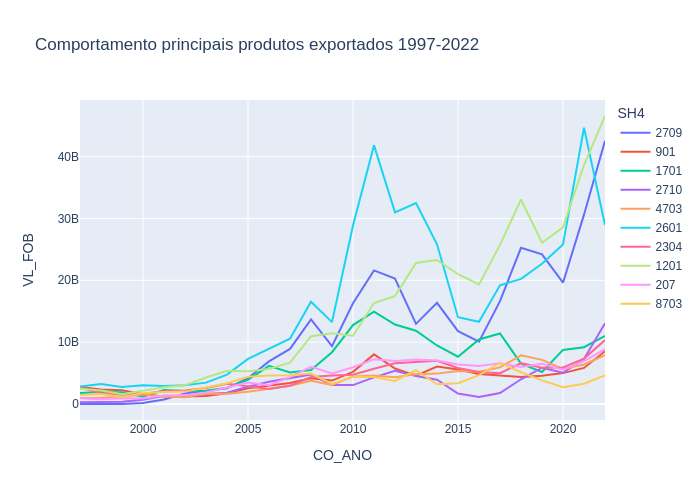

Conforme evidenciado no gráfico ao longo da história, o minério de ferro e a soja têm consistentemente ocupado as posições de destaque no que diz respeito ao valor das exportações brasileiras. Como será detalhado no tópico "Principais Parceiros Comerciais do Brasil", a China se destaca como um dos principais parceiros comerciais do Brasil, desempenhando um papel fundamental devido à sua significativa demanda por esses produtos. Essa demanda tem sido benéfica para o Brasil, impulsionando suas exportações.

Além da China, os Estados Unidos, outro parceiro comercial de grande importância, desempenha um papel crucial no mercado da siderurgia, parte de sua demanda por ferro é suprida por empresas brasileiras. Esses fatores consolidam o ferro como um elemento de destaque no mercado brasileiro. No entanto, em 2022, seu preço no mercado internacional sofreu uma queda, levando-o a ceder espaço para o petróleo durante esse ano.

Outro fator relevante para o aumento das exportações de petróleo pelo Brasil nos últimos anos é a descoberta das reservas de pré-sal e a eficiente operacionalização de sua extração. Esses avanços permitiram que o Brasil se destacasse como um importante player nesse setor, contribuindo para o crescimento das exportações de petróleo.

```
2601 - Minérios de ferro e seus concentrados, incluídas as pirites de ferro ustuladas (cinzas de pirites)
1201 - Soja, mesmo triturada
2709 - Óleos brutos de petróleo ou de minerais betuminosos
1701 - Açúcares de cana ou de beterraba e sacarose quimicamente pura, no estado sólido
2304 - Tortas e outros resíduos sólidos da extração do óleo de soja
4703 - Pastas químicas de madeira, à soda ou ao sulfato, exceto pastas para dissolução
2710 - Óleos de petróleo ou de minerais betuminosos, exceto óleos brutos; preparações não especificadas nem compreendidas noutras posições, contendo, em peso, 70 % ou mais de óleos de petróleo ou de minerais betuminosos, os quais devem constituir o seu elemento
```

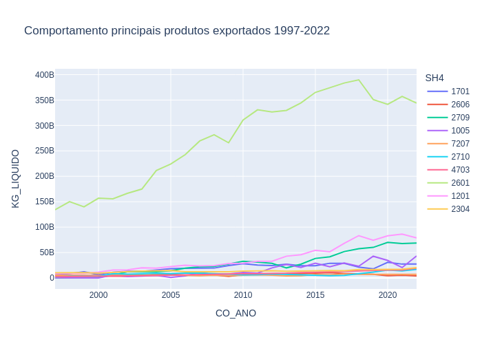

Ao examinar os produtos exportados, fica evidente a vitalidade da indústria mineradora, especialmente no que diz respeito ao minério de ferro, para a economia brasileira. Ao longo de todo o período analisado, o minério de ferro se mantém como o produto de maior volume de exportação, embora em termos financeiros possa perder posições devido às flutuações nos preços internacionais desse recurso.

## Destaque para Estados e Municípios Brasileiros

Para obter uma compreensão mais detalhada das origens das exportações brasileiras, é fundamental analisar as regiões e os municípios que contribuem significativamente em termos de volume financeiro e quantidade em quilogramas líquidos. As localidades brasileiras podem ser classificadas em uma hierarquia, com a região no nível mais amplo e o município no nível mais específico. Para uma análise abrangente das exportações do Brasil, será analisada dois níveis dessa hierarquia: o municipal e o estadual.

Inicialmente, inicialmente a análise irá se concentrar nas exportações a nível municipal e, posteriormente, examinaremos os estados. É importante destacar que a Região Sudeste do Brasil é conhecida por seu alto desenvolvimento em termos de Produto Interno Bruto (PIB), emprego e renda. Portanto, é de se esperar que a maior parte das exportações tenha origem nessa região, com destaque para estados como Minas Gerais, que exporta minério de ferro, e Rio de Janeiro, que exporta petróleo.

### Municípios

|  | CO_ANO | CO_MES | SH4 | CO_PAIS | SG_UF_MUN | CO_MUN | KG_LIQUIDO | VL_FOB | DATA_COMPLETA | CO_SH4 | NO_SH4_POR | CO_SH2 | NO_SH2_POR | CO_NCM_SECROM | NO_SEC_POR | CO_MUN_GEO | NO_MUN | NO_MUN_MIN | SG_UF |
| --- | --- | --- | --- | --- | --- | --- | --- | --- | --- | --- | --- | --- | --- | --- | --- | --- | --- | --- | --- |
| 0 | 1997 | 11 | 8708 | 65 | PR | 4125506 | 90.0 | 3523 | 1997-11 | 8708 | Partes e acessórios dos veículos automóveis da... | 87 | Veículos automóveis, tratores, ciclos e outros... | XVII | Material de transporte | 4125506 | SAO JOSE DOS PINHAIS | São José dos Pinhais | PR |
| 1 | 1997 | 11 | 8708 | 149 | SP | 3448708 | 324.0 | 2502 | 1997-11 | 8708 | Partes e acessórios dos veículos automóveis da... | 87 | Veículos automóveis, tratores, ciclos e outros... | XVII | Material de transporte | 3448708 | SAO BERNARDO DO CAMPO | São Bernardo do Campo | SP |
| 2 | 1997 | 11 | 9403 | 275 | SC | 4215802 | 909015.0 | 2367314 | 1997-11 | 9403 | Outros móveis e suas partes | 94 | Móveis; mobiliário médico-cirúrgico, colchões,... | XX | Mercadorias e produtos diversos | 4215802 | SAO BENTO DO SUL | São Bento do Sul | SC |
| 3 | 1997 | 11 | 6104 | 586 | SC | 4208906 | 710.0 | 23344 | 1997-11 | 6104 | Fatos de saia-casaco, conjuntos, casacos, vest... | 61 | Vestuário e seus acessórios, de malha | XI | Matérias têxteis e suas obras | 4208906 | JARAGUA DO SUL | Jaraguá do Sul | SC |
| 4 | 1997 | 11 | 8419 | 196 | SP | 3403208 | 96300.0 | 382100 | 1997-11 | 8419 | Aparelhos e dispositivos, mesmo aquecidos elec... | 84 | Reatores nucleares, caldeiras, máquinas, apare... | XVI | Máquinas e aparelhos, material elétrico e suas... | 3403208 | ARARAQUARA | Araraquara | SP |

|  | NO_MUN | VL_FOB |
| --- | --- | --- |
| 2912 | SAO PAULO | 182045801489 |
| 2534 | RIO DE JANEIRO | 145541497199 |
| 2173 | PARAUAPEBAS | 122579505188 |
| 2877 | SAO JOSE DOS CAMPOS | 109364811926 |
| 978 | DUQUE DE CAXIAS | 88551154544 |
| 2161 | PARANAGUA | 83357577426 |
| 141 | ANGRA DOS REIS | 82969292957 |
| 2769 | SAO BERNARDO DO CAMPO | 79715448122 |
| 2759 | SANTOS | 72216560006 |
| 3328 | VITORIA | 70181573560 |

|  | NO_MUN | KG_LIQUIDO |
| --- | --- | --- |
| 2173 | PARAUAPEBAS | 2.174583e+12 |
| 1376 | ITABIRA | 8.512330e+11 |
| 2015 | NOVA LIMA | 6.828832e+11 |
| 3328 | VITORIA | 6.405582e+11 |
| 2100 | OURO PRETO | 4.787950e+11 |
| 1388 | ITAGUAI | 3.808218e+11 |
| 588 | CANAA DOS CARAJAS | 3.771710e+11 |
| 2534 | RIO DE JANEIRO | 3.693627e+11 |
| 131 | ANCHIETA | 3.390195e+11 |
| 2912 | SAO PAULO | 3.087993e+11 |

Ao avaliar as exportações por Valores monetários nota-se que os principais municipios exportadores são São Paulo e Rio de Janeiro, essas localidades tem um histórico de desenvolvimento voltado para produtos com maior valor agregado, com o setor de serviços e comercial mais complexos que em outras cidades do Brasil. No entando, ao analisar os dez principais municípios exportadores por quantidade exportada, a imagem é diferente. Na segunda as principais cidades estão intrisicamente relacionada com a cadeia minerária brasileira. Parauapebas, Itabira e Nova Lima são conhecido por suas atividades de mineração, principalmente o minério de ferro. Vitória, por sua ves, desempenha um papel crucial como ponto de escoamento dos produtos relacionados a cidade minéria. Esse produto é transportado por meio de trens na estrada ferra vitória-minas, conhecida como EFVM.

Essa diferença entre nas exportações brasileiras, demonstra a complexidade da carteira de produtos exportados no país.

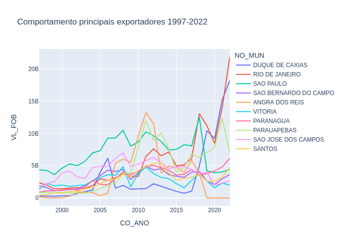

Apesar de São Paulo manter o maior volume financeiro acumulado de exportações em toda a série histórica, é evidente que desde 2008 o município tem perdido sua influência nas transações internacionais do país. Nesse período, o Rio de Janeiro e, especialmente, Duque de Caxias, têm assumido posições de destaque. O notável crescimento de Duque de Caxias merece uma análise mais aprofundada, sobretudo devido ao fato de o município ter superado o Rio de Janeiro nos anos de 2020-2021. É importante ressaltar que a queda no valor financeiro das exportações de Parauapebas está diretamente ligada à redução do valor do minério de ferro.

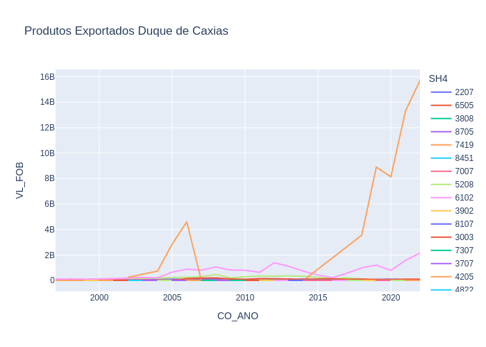

```
['Óleos brutos de petróleo ou de minerais betuminosos']
```

Com base no gráfico apresentado, é evidente que o principal impulsionador do crescimento de Duque de Caxias nos últimos anos é a exportação de óleos brutos de petróleo ou minerais betuminosos. Após a análise dos valores monetario, se faz necessário compreender quais são os principais muunicípios exportadores em termos de Kilograma exportado.

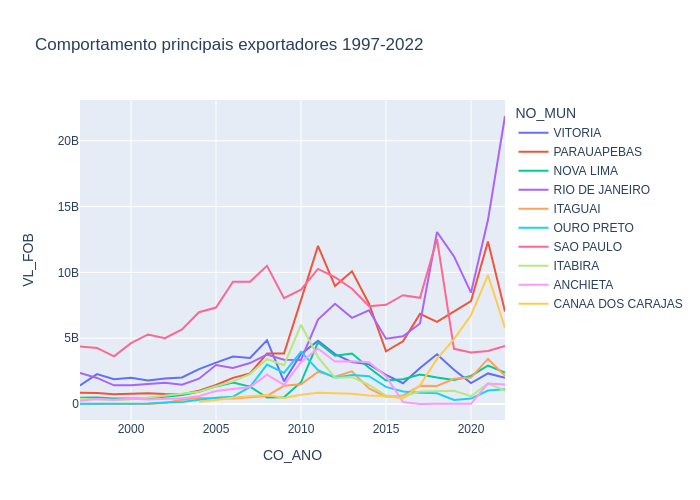

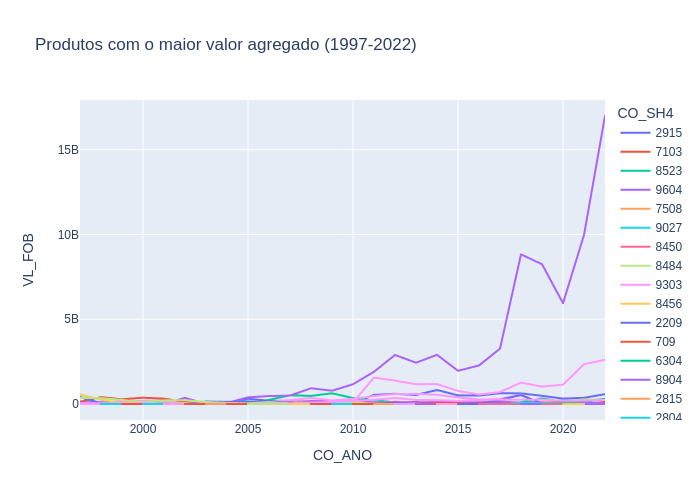

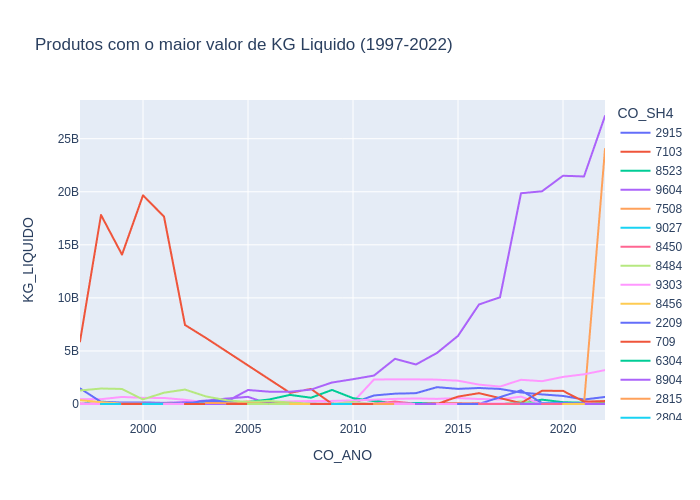

```
Em termos de "KG_LIQUIDO", o segundo principal produto do Rio de Janeiro é: ['Outras embarcações, incluídos os navios de guerra e os barcos salva-vidas, exceto os barcos a remos']
O principal produto exportado no Rio de Janeiro é: ['Óleos brutos de petróleo ou de minerais betuminosos']
```

Assim como ocorreu em Duque de Caxias, o município do Rio de Janeiro foi favorecido pelo valor dos produtos relacionados a "Óleos brutos de petróleo ou de minerais betuminosos". No entanto, é importante considerar o impacto do produto denominado "Outras embarcações, incluindo navios de guerra e barcos salva-vidas, com exceção de barcos a remos" nas exportações, especialmente em termos de 'KG_LIQUIDO'. A análise temporal destacou esses dois municípios no estado do Rio de Janeiro como principais exportadores do Brasil nos últimos anos. No entanto, a próxima etapa da análise, que contemplará os estados, permitirá uma compreensão mais abrangente do agregado dos municípios nas exportações brasileiras.

### Estados

|  | CO_ANO | CO_MES | SH4 | CO_PAIS | SG_UF_MUN | CO_MUN | KG_LIQUIDO | VL_FOB | DATA_COMPLETA | NO_UF |
| --- | --- | --- | --- | --- | --- | --- | --- | --- | --- | --- |
| 0 | 1997 | 11 | 8708 | 65 | PR | 4125506 | 90.0 | 3523 | 1997-11 | Paraná |
| 1 | 1997 | 11 | 8708 | 149 | SP | 3448708 | 324.0 | 2502 | 1997-11 | São Paulo |
| 2 | 1997 | 11 | 9403 | 275 | SC | 4215802 | 909015.0 | 2367314 | 1997-11 | Santa Catarina |
| 3 | 1997 | 11 | 6104 | 586 | SC | 4208906 | 710.0 | 23344 | 1997-11 | Santa Catarina |
| 4 | 1997 | 11 | 8419 | 196 | SP | 3403208 | 96300.0 | 382100 | 1997-11 | São Paulo |
| ... | ... | ... | ... | ... | ... | ... | ... | ... | ... | ... |
| 18365939 | 2022 | 9 | 2201 | 445 | SP | 3448500 | 1260.0 | 328 | 2022-9 | São Paulo |
| 18365940 | 2022 | 7 | 9603 | 586 | RS | 4304804 | 24.0 | 350 | 2022-7 | Rio Grande do Sul |
| 18365941 | 2022 | 9 | 8527 | 239 | PR | 4120804 | 234.0 | 34731 | 2022-9 | Paraná |
| 18365942 | 2022 | 1 | 203 | 767 | PA | 1506807 | 30.0 | 226 | 2022-1 | Pará |
| 18365943 | 2022 | 1 | 8527 | 63 | SP | 3452403 | 7.0 | 2246 | 2022-1 | São Paulo |

18365944 rows × 10 columns

|  | NO_UF | VL_FOB |
| --- | --- | --- |
| 0 | São Paulo | 1211481375810 |
| 1 | Minas Gerais | 510276244703 |
| 2 | Rio de Janeiro | 453714254839 |
| 3 | Paraná | 348930338180 |
| 4 | Rio Grande do Sul | 329596106667 |
| 5 | Pará | 272457161460 |
| 6 | Santa Catarina | 211647515912 |
| 7 | Mato Grosso | 200474927209 |
| 8 | Espírito Santo | 188387816326 |
| 9 | Bahia | 171465401812 |

|  | NO_UF | KG_LIQUIDO |
| --- | --- | --- |
| 0 | Minas Gerais | 3.351016e+12 |
| 1 | Pará | 2.946699e+12 |
| 2 | Rio de Janeiro | 1.297365e+12 |
| 3 | São Paulo | 1.205734e+12 |
| 4 | Espírito Santo | 1.145988e+12 |
| 5 | Paraná | 5.678383e+11 |
| 6 | Mato Grosso | 5.096493e+11 |
| 7 | Rio Grande do Sul | 3.847394e+11 |
| 8 | Bahia | 2.473596e+11 |
| 9 | Maranhão | 2.082713e+11 |

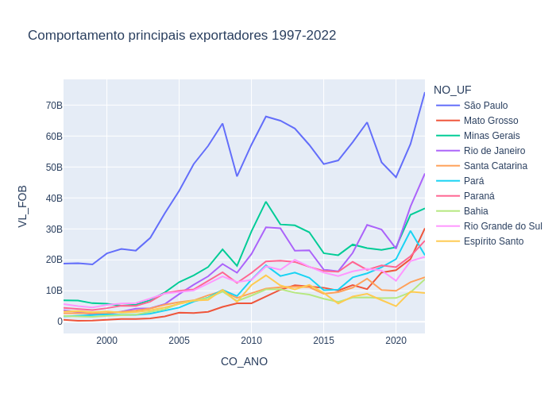

De acordo com o gráfico, historicamente, São Paulo tem desempenhado o papel de principal estado exportador do Brasil. Seus valores atingiram um pico notável de 60 bilhões de reais em 2008, durante a crise do subprime. Esse marco foi ligeiramente superado nos anos de 2011 e 2018, mas foi verdadeiramente ultrapassado em 2022, quando as exportações alcançaram a impressionante marca de 74 bilhões de reais. Entre os anos de 1997 e 2017, Minas Gerais consistentemente ocupou a segunda posição em termos de valor de exportação. No entanto, a partir de 2018, o Rio de Janeiro começou a superar Minas Gerais, ficando apenas ligeiramente atrás, exceto no ano de 2020. Essas variações podem ser explicadas pelas flutuações nos preços e na demanda por minério de ferro e petróleo, que são as principais commodities exportadas por esses estados.

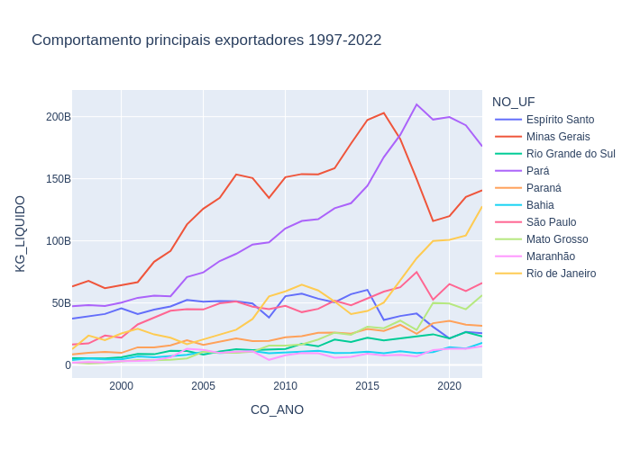

## Análise dos Períodos Críticos

O sistema capitalista é, por sua natureza, cíclico. Isso significa que ele passa por períodos de crescimento econômico e estagnação econômica de forma recorrente. O crescimento econômico muitas vezes está diretamente ligado à introdução de novas tecnologias disruptivas, que possibilitam o aumento da oferta de determinados bens ou serviços, reduzindo custos ou maximizando lucros, conforme destacado por Schumpeter em 1939. Por outro lado, os momentos de estagnação econômica costumam estar associados ao aumento das taxas de juros, inflação, redução da demanda, entre outros fatores.

Ao longo da história, testemunhamos diversas crises no sistema capitalista que resultaram em grandes perdas para empresários e consumidores. A mais famosa delas foi a Crise de 1929, que culminou no colapso da bolsa de valores. Mais recentemente, na história contemporânea, tivemos a Crise do Subprime em setembro de 2008, que levou à falência do banco de investimento Lehman Brothers. Essa crise foi desencadeada pelo aumento dos índices de inadimplência no pagamento de hipotecas e atingiu seu ápice com a quebra do Lehman Brothers, na época o maior banco de investimentos dos Estados Unidos (Freitas et al., 2016). Devido à sua origem no maior sistema financeiro do mundo, essa crise afetou diversos países, incluindo o Brasil.

Para além das crises do sistema financeiro, recentemente o mundo foi impacto pela primeira pandemia desde a Gripe Espanhola, mais de um secúlo atras. A pandemia de COVID-19, assim como a crise do subprime impactou o sistema financeiro mundial e consequentemente as exportações dos países. Devido as restrições necessárias para conter o vírus diverso países decretaram lockdown em cidades fazendo com o setor industrial parasse, diminuindo a demanda por deteminados produtos. Contudo essa diminuição da demanda e consequentemente da oferta fez com que o preço de algumas comodities subissem, podendo ter tido impactos positivos na balança comercial de alguns países o Brasil incluso.

Nesse contexto, a análise que se segue busca compreender o comportamento das exportações brasileiras no período de 2008 a 2010, considerando o impacto da Crise do Subprime e os anos de 2020-2022 que contempla a COVID-19

|  | CO_ANO | KG_LIQUIDO | VL_FOB | %_Val | %_KG |
| --- | --- | --- | --- | --- | --- |
| 0 | 1997 | 2.088178e+11 | 52947495532 | NaN | NaN |
| 1 | 1998 | 2.301530e+11 | 51076603549 | -3.533485 | 10.217143 |
| 2 | 1999 | 2.285435e+11 | 47945909310 | -6.129410 | -0.699315 |
| 3 | 2000 | 2.445374e+11 | 54993159648 | 14.698335 | 6.998165 |
| 4 | 2001 | 2.725458e+11 | 58032294243 | 5.526387 | 11.453606 |
| 5 | 2002 | 2.954618e+11 | 60147158103 | 3.644288 | 8.408150 |
| 6 | 2003 | 3.210013e+11 | 72776746690 | 20.997814 | 8.643925 |
| 7 | 2004 | 3.756365e+11 | 95121672369 | 30.703386 | 17.020249 |
| 8 | 2005 | 3.968244e+11 | 118597835407 | 24.680141 | 5.640523 |
| 9 | 2006 | 4.242580e+11 | 137581151209 | 16.006461 | 6.913279 |
| 10 | 2007 | 4.614655e+11 | 159816383833 | 16.161540 | 8.770018 |
| 11 | 2008 | 4.687614e+11 | 195764624177 | 22.493464 | 1.581039 |
| 12 | 2009 | 4.552556e+11 | 151791674186 | -22.462153 | -2.881177 |
| 13 | 2010 | 5.197414e+11 | 200434134826 | 32.045539 | 14.164760 |
| 14 | 2011 | 5.440857e+11 | 253666309507 | 26.558438 | 4.683911 |
| 15 | 2012 | 5.459323e+11 | 239952538158 | -5.406225 | 0.339411 |
| 16 | 2013 | 5.579524e+11 | 232544255606 | -3.087395 | 2.201744 |
| 17 | 2014 | 5.763956e+11 | 220923236838 | -4.997336 | 3.305526 |
| 18 | 2015 | 6.360293e+11 | 186782355063 | -15.453731 | 10.345967 |
| 19 | 2016 | 6.448919e+11 | 179526129214 | -3.884856 | 1.393423 |
| 20 | 2017 | 6.917433e+11 | 214988108353 | 19.753102 | 7.264998 |
| 21 | 2018 | 7.055500e+11 | 231889523399 | 7.861558 | 1.995926 |
| 22 | 2019 | 6.781081e+11 | 221126807647 | -4.641312 | -3.889438 |
| 23 | 2020 | 6.974466e+11 | 209180241655 | -5.402586 | 2.851839 |
| 24 | 2021 | 7.003872e+11 | 280814577460 | 34.245269 | 0.421619 |
| 25 | 2022 | 7.406480e+11 | 334136038220 | 18.988138 | 5.748371 |

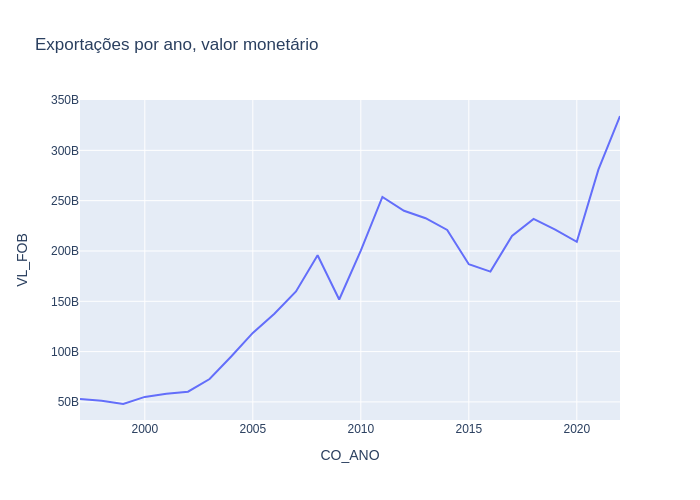

Conforme demonstrado na tabela e no gráfico acima, as exportações brasileiras foram relativamente resilientes à crise do subprime, experimentando uma queda moderada de 22% em 2009. No entanto, elas se recuperaram rapidamente, superando os níveis pré-crise já em 2010, com um notável aumento de 32% em relação ao ano anterior. Esse desempenho mais sólido no Brasil pode ser atribuído à composição predominantemente composta por commodities em sua cesta de produtos exportados. Mesmo durante a crise, esses itens permaneceram fundamentais para a eficiência econômica, o que levanta a possibilidade de que o Brasil tenha aproveitado a situação, uma vez que suas exportações continuaram a crescer nos anos subsequentes à crise.

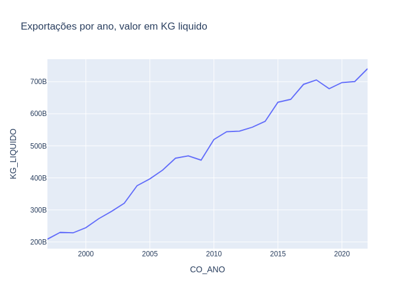

## Principais parceiros comercias do Brasil

Compreendidos os principais produtos exportados, junto a analise dos momentos de crise e das localidades do Brasil que mais exportam produto, faz se necessário compreender quais são os países que estes produtos são endereçados. A localidade de destino é muito importante, pois momentos de recessões nestas economias podem impactar diretamente as exportações brasileiro, causando um choque na economia. Por exemplo caso a China diminua a demanda pelo ferro Brasileiro o resultado da balança comercial brasileira será impactado negativamente, contudo com o aumento do estoque de ferro este produto poderá abastecer o mercado interno a um preço menor, o mesmo vale para produtos como a Soja.

Ao longo da história o Brasil teve diferentes parceiros comerciais que demandavam boa parte dos produtos confeccionados no mercado interno, a saber: Portugal, Inglaterra, Estados Unidos e China. Com a analise dos dados busca compreender a dinâmica destes parceiros na história recente

```
<class 'pandas.core.frame.DataFrame'>
Int64Index: 19109712 entries, 0 to 19109711
Data columns (total 20 columns):
 #   Column         Dtype
---  ------         -----
 0   CO_ANO         int64
 1   CO_MES         int64
 2   SH4            int64
 3   CO_PAIS        int64
 4   SG_UF_MUN      object
 5   CO_MUN         int64
 6   KG_LIQUIDO     float64
 7   VL_FOB         int64
 8   DATA_COMPLETA  object
 9   CO_SH4         int64
 10  NO_SH4_POR     object
 11  CO_SH2         int64
 12  NO_SH2_POR     object
 13  CO_NCM_SECROM  object
 14  NO_SEC_POR     object
 15  CO_MUN_GEO     int64
 16  NO_MUN         object
 17  NO_MUN_MIN     object
 18  SG_UF          object
 19  NO_PAIS        object
dtypes: float64(1), int64(9), object(10)
memory usage: 3.0+ GB
```

|  | NO_PAIS | VL_FOB |
| --- | --- | --- |
| 51 | China | 774756950145 |
| 79 | Estados Unidos | 569232818702 |
| 11 | Argentina | 308180073311 |
| 183 | Países Baixos (Holanda) | 187498196750 |
| 4 | Alemanha | 133802345868 |
| 122 | Japão | 121135365028 |
| 50 | Chile | 99192755098 |
| 161 | México | 91941354381 |
| 118 | Itália | 86680883435 |
| 78 | Espanha | 81178270441 |

Conforme evidenciado na tabela, em termos históricos, a China ocupa a posição de principal parceiro comercial do Brasil, seguida pelos Estados Unidos e pela Argentina. Desde o início dos anos 2000, a China tem mantido um crescimento econômico acima da média, o qual tem beneficiado países como o Brasil, que desempenham um papel crucial na oferta de produtos primários, conhecidos como commodities.

Historicamente, os Estados Unidos também têm sido um parceiro comercial significativo para o Brasil, como será destacado na análise histórica a seguir. Durante anos, foram os Estados Unidos que ocuparam o posto de principal parceiro comercial do Brasil, até a ascensão da China.

A Argentina, uma das maiores economias da América Latina, encontra-se geograficamente próxima do Brasil, o que facilita as negociações bilaterais entre os dois países. Ao longo da história, Brasil e Argentina têm desempenhado papéis cruciais como parceiros comerciais dentro do contexto latino-americano.

|  | NO_PAIS | KG_LIQUIDO |
| --- | --- | --- |
| 51 | China | 4.498169e+12 |
| 122 | Japão | 8.131933e+11 |
| 79 | Estados Unidos | 7.098798e+11 |
| 183 | Países Baixos (Holanda) | 5.170100e+11 |
| 4 | Alemanha | 4.574936e+11 |
| 61 | Coreia do Sul | 3.921123e+11 |
| 87 | França | 3.165761e+11 |
| 118 | Itália | 2.959315e+11 |
| 11 | Argentina | 2.802109e+11 |
| 145 | Malásia | 2.634393e+11 |

Quando analisamos os dados em termos de quilogramas líquidos, observamos que os países listados são semelhantes à tabela de valores monetários. No entanto, a classificação dos países-chave é diferente, e a China emerge como a líder indiscutível. A Argentina, que é o terceiro maior importador de produtos brasileiros em termos financeiros, cai para a nona posição. Isso ocorre devido à natureza do comércio entre esses dois países, que está associado a uma cadeia produtiva mais sofisticada, resultando em produtos com maior valor agregado.

Os Estados Unidos, que ocupavam a segunda posição, agora ficam em terceiro lugar, atrás do Japão. O Japão, um país com recursos naturais escassos, depende em certa medida dos produtos brasileiros.

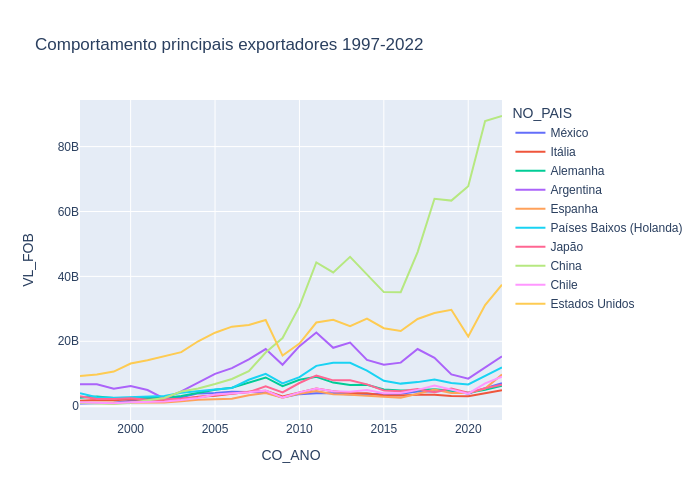

Mesmo durante o período que abrange a crise da COVID-19, a China continuou a demandar recursos brasileiros de forma ascendente, enquanto outros países diminuíram sua participação ou apresentaram um crescimento mais modesto.

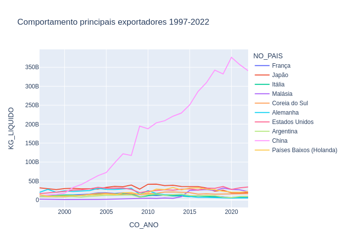

Ao analisar as exportações em termos de quilogramas líquidos, fica evidente que o ascensão da China teve início no início da década de 2000, mais precisamente em 2002, quando o país se tornou o principal destino dos produtos brasileiros. Outro país que chama a atenção é a Malásia, que experimentou um aumento significativo nas exportações a partir de 2013, chegando a ultrapassar os Estados Unidos em 2020 e assumindo a posição de segundo principal parceiro do Brasil nesse ano. Com base na trajetória observada com a China, a Malásia demonstra potencial para se tornar um parceiro comercial importante para o Brasil no futuro.

# Conclusão

A compreensão da composição das exportações do Brasil possui diversas aplicações, desde a avaliação de investimentos até o desenvolvimento de estratégias para identificar mercados-alvo e compreender os motivos por trás do aumento de preços de certos produtos. Isso ocorre porque a redução da oferta interna de um bem ou serviço devido às exportações pode resultar em aumento de seu preço no mercado doméstico. Um exemplo disso é a soja, que, como destacado ao longo deste documento, desempenha um papel fundamental no mercado chinês. Em 2022, a soja se tornou o principal produto exportado pelo Brasil, exercendo um impacto direto sobre o preço do óleo de soja, que é um item crucial para as famílias brasileiras.

Outro elemento de grande importância para a balança comercial brasileira é o minério de ferro. Em termos de peso líquido, o minério de ferro lidera as exportações do Brasil e, em termos monetários, frequentemente oscila entre a primeira e a terceira posição, competindo com o petróleo e a soja. Além disso, a análise ressalta a presença de produtos relacionados ao setor automobilístico nas exportações, especialmente automóveis de passageiros. Embora esse produto tenha perdido participação na composição das exportações brasileiras, ele ilustra a complexidade da indústria brasileira.

# Referências

GONTIJO, C. **AS DUAS VIAS DO PRINCÍPIO DAS VANTAGENS COMPARATIVAS DE DAVID RICARDO E O PADRÃO-OURO: UM ENSAIO CRÍTICO**. Revista de Economia Política. vol.27. nº 3. pp. 413-430. julho-setembro/2007

LIMA, S. C. **DA SUBSTITUIÇÃO DE IMPORTAÇÕES AO BRASIL POTÊNCIA: CONCEPÇÕES DO DESENVOLVIMENTO 1964-1979** Aurora. Ano V. nº 7. Janeiro/2011. https://doi.org/10.36311/1982-8004.2010.v4n1.1243

SCHUMPETER, J. **Capitalismo, Socialismo e Democracia**. 1ª. ed. São Paulo: Unesp, v. I, 2017.

Freitas, K. A. et. al. **CRISE DO SUBPRIME: AS PERSPECTIVAS DO PENSAMENTO NEOCLÁSSICAS E COMPORTAMENTAIS**. Revista FSA, Teresina. v.13. nº 2. pp. 102-125. março-abril/2016. ISSN 2317-2983. http://dx.doi.org/10.12819/2016.13.2.6

[output not shown]